# Untitled

Salome Isch, Adriana Ricklin

10 9 2020

Dataset: 2019_verkehrszaehlungen_werte_fussgaenger_velo This document shows the quarter hourly count of pedestrians and bikers passing at different counting stations. Source: https://data.stadt-zuerich.ch/dataset/ted_taz_verkehrszaehlungen_werte_fussgaenger_velo/resource/33b3e7d3-f662-43e8-b018-e4b1a254f1f4?inner_span=True

Dataset: wetter  
***

First, the required libraries are set up:

```r
# 1.1.1 Libraries
library(dplyr)
```

```r
library(stringr)
library(dplyr)
library(ggplot2)
library(lattice)
```

We further check if we are in the correct working directory:

```r
#get working directory
getwd()
```

```
## [1] "D:/home/adriana/GitHub/r-bootcamp"
```

# 1 Dataset

```r
#read in data
zaehlung <- read.csv("2019_verkehrszaehlungen_werte_fussgaenger_velo_bereinigt.csv", sep=";", header = TRUE)
colnames(zaehlung)[1] <- "FK_ZAEHLER"
#structure of the dataset
str(zaehlung)
```

```
## 'data.frame':    83273 obs. of  10 variables:
##  $ FK_ZAEHLER : Factor w/ 4 levels "ECO07091438",..: 3 4 3 4 3 4 3 4 3 4 ...
##  $ FK_STANDORT: int  2641 2642 2641 2642 2641 2642 2641 2642 2641 2642 ...
##  $ DATUM      : Factor w/ 29275 levels "2019-01-01T00:00",..: 1 1 2 2 3 3 4 4 5 5 ...
##  $ VELO_IN    : int  NA NA NA NA NA NA NA NA NA NA ...
##  $ VELO_OUT   : int  NA NA NA NA NA NA NA NA NA NA ...
##  $ FUSS_IN    : int  25 35 11 18 0 8 8 4 4 8 ...
##  $ FUSS_OUT   : int  5 17 4 7 25 13 22 29 16 5 ...
##  $ OST        : int  2682813 2683020 2682813 2683020 2682813 2683020 2682813 2683020 2682813 2683020 ...
##  $ NORD       : int  1245490 1244136 1245490 1244136 1245490 1244136 1245490 1244136 1245490 1244136 ...
##  $ KATEGORIE  : logi  NA NA NA NA NA NA ...
```

```r
head(zaehlung)
```

```
##    FK_ZAEHLER FK_STANDORT            DATUM VELO_IN VELO_OUT FUSS_IN FUSS_OUT
## 1 U15G3104443        2641 2019-01-01T00:00      NA       NA      25        5
## 2 U15G3104446        2642 2019-01-01T00:00      NA       NA      35       17
## 3 U15G3104443        2641 2019-01-01T00:15      NA       NA      11        4
## 4 U15G3104446        2642 2019-01-01T00:15      NA       NA      18        7
## 5 U15G3104443        2641 2019-01-01T00:30      NA       NA       0       25
## 6 U15G3104446        2642 2019-01-01T00:30      NA       NA       8       13
##       OST    NORD KATEGORIE
## 1 2682813 1245490        NA
## 2 2683020 1244136        NA
## 3 2682813 1245490        NA
## 4 2683020 1244136        NA
## 5 2682813 1245490        NA
## 6 2683020 1244136        NA
```

```r
wetter <- read.csv("wetter.csv", sep=";", header = TRUE)
#structure of the dataset
str(zaehlung)
```

```
## 'data.frame':    83273 obs. of  10 variables:
##  $ FK_ZAEHLER : Factor w/ 4 levels "ECO07091438",..: 3 4 3 4 3 4 3 4 3 4 ...
##  $ FK_STANDORT: int  2641 2642 2641 2642 2641 2642 2641 2642 2641 2642 ...
##  $ DATUM      : Factor w/ 29275 levels "2019-01-01T00:00",..: 1 1 2 2 3 3 4 4 5 5 ...
##  $ VELO_IN    : int  NA NA NA NA NA NA NA NA NA NA ...
##  $ VELO_OUT   : int  NA NA NA NA NA NA NA NA NA NA ...
##  $ FUSS_IN    : int  25 35 11 18 0 8 8 4 4 8 ...
##  $ FUSS_OUT   : int  5 17 4 7 25 13 22 29 16 5 ...
##  $ OST        : int  2682813 2683020 2682813 2683020 2682813 2683020 2682813 2683020 2682813 2683020 ...
##  $ NORD       : int  1245490 1244136 1245490 1244136 1245490 1244136 1245490 1244136 1245490 1244136 ...
##  $ KATEGORIE  : logi  NA NA NA NA NA NA ...
```

```r
head(zaehlung)
```

```
##    FK_ZAEHLER FK_STANDORT            DATUM VELO_IN VELO_OUT FUSS_IN FUSS_OUT
## 1 U15G3104443        2641 2019-01-01T00:00      NA       NA      25        5
## 2 U15G3104446        2642 2019-01-01T00:00      NA       NA      35       17
## 3 U15G3104443        2641 2019-01-01T00:15      NA       NA      11        4
## 4 U15G3104446        2642 2019-01-01T00:15      NA       NA      18        7
## 5 U15G3104443        2641 2019-01-01T00:30      NA       NA       0       25
## 6 U15G3104446        2642 2019-01-01T00:30      NA       NA       8       13
##       OST    NORD KATEGORIE
## 1 2682813 1245490        NA
## 2 2683020 1244136        NA
## 3 2682813 1245490        NA
## 4 2683020 1244136        NA
## 5 2682813 1245490        NA
## 6 2683020 1244136        NA
```

The head of our dataset indicates that the traffic counters did not work for both pedestrians and bikers but only specifically for one of each. We thus categorize the counting stations accordingly and summarize the data into one shared column.

As the traffic counters further made a difference whether one went from direction A to B or vice versa (x_IN <-> x_OUT), we take those numbers together as we are solely interested in the total number of pedestrians / bikers. These numbers are stored in the column “UNIDIR” which is an abbreviation for unidirectional.

##### 1.0.0.0.1 **1.1 Preparation of the datasets**

```r
#1.1.1 Prepare dataset pedestrians and bikers
##changing the FK_ZAEHLER to an indicator if bike or pedestrians are measured
zaehlung$FK_ZAEHLER <- as.character(zaehlung$FK_ZAEHLER)
zaehlung$FK_ZAEHLER[zaehlung$FK_ZAEHLER == "U15G3104443"] <- "fussgaenger"
zaehlung$FK_ZAEHLER[zaehlung$FK_ZAEHLER == "U15G3104446"] <- "fussgaenger"
zaehlung$FK_ZAEHLER[zaehlung$FK_ZAEHLER == "ECO09113499"] <- "velo"
zaehlung$FK_ZAEHLER[zaehlung$FK_ZAEHLER == "ECO07091438"] <- "velo"
zaehlung$FK_ZAEHLER <- as.factor(zaehlung$FK_ZAEHLER)
zaehlung$FK_STANDORT <- as.factor(zaehlung$FK_STANDORT)

#only show hours not minutes
zaehlung$DATUM <- str_sub(zaehlung$DATUM, end = -4)

#getting the total of movements, independent from their direction
zaehlung[is.na(zaehlung)] <- 0
zaehlung[, "IN"] <- zaehlung[4]+zaehlung[6]
zaehlung[, "OUT"] <- zaehlung[5] + zaehlung[7]
zaehlung[, "UNIDIR"] <- zaehlung[4] + zaehlung [5] + zaehlung[6] +  zaehlung[7]

#
zaehlung[, "TAGESZEIT"] <-str_sub(zaehlung$DATUM, 12)
zaehlung$TAGESZEIT[zaehlung$TAGESZEIT  <= "06"] <- "morgen"
zaehlung$TAGESZEIT[zaehlung$TAGESZEIT  <= "12"] <- "vormittag"
zaehlung$TAGESZEIT[zaehlung$TAGESZEIT  <= "18"] <- "nachmittag"
zaehlung$TAGESZEIT[zaehlung$TAGESZEIT  <= "24"] <- "abend"
zaehlung$TAGESZEIT <- as.factor(zaehlung$TAGESZEIT)

head(zaehlung)
```

```
##    FK_ZAEHLER FK_STANDORT         DATUM VELO_IN VELO_OUT FUSS_IN FUSS_OUT
## 1 fussgaenger        2641 2019-01-01T00       0        0      25        5
## 2 fussgaenger        2642 2019-01-01T00       0        0      35       17
## 3 fussgaenger        2641 2019-01-01T00       0        0      11        4
## 4 fussgaenger        2642 2019-01-01T00       0        0      18        7
## 5 fussgaenger        2641 2019-01-01T00       0        0       0       25
## 6 fussgaenger        2642 2019-01-01T00       0        0       8       13
##       OST    NORD KATEGORIE IN OUT UNIDIR TAGESZEIT
## 1 2682813 1245490         0 25   5     30    morgen
## 2 2683020 1244136         0 35  17     52    morgen
## 3 2682813 1245490         0 11   4     15    morgen
## 4 2683020 1244136         0 18   7     25    morgen
## 5 2682813 1245490         0  0  25     25    morgen
## 6 2683020 1244136         0  8  13     21    morgen
```

```r
#calculate the total of movements of pedestrians and bikers hourly
aggregated_listFK <- aggregate(UNIDIR ~ FK_ZAEHLER + TAGESZEIT + OST + NORD + FK_STANDORT + DATUM, zaehlung, sum)
```

```r
#1.1.2 Prepare dataset Weather

#wetter$wind_force_avg_10min <- as.factor(wetter$wind_force_avg_10min)
#apply(wetter, MARGIN = 2, FUN = anyNA)

#only show hours not minutes
wetter$timestamp_cet <- str_sub(wetter$timestamp_cet, end = -7)
```

```r
#calculate the mean of wind force, air temperature and humidity per hour, and the sum of precipitation per hour

#aggregated_listWETTER <- aggregate(timestamp_cet ~ wind_force_avg_10min + air_temperature + precipitation, wetter, FUN = "mean")

aggregated_Wind <- aggregate(wind_force_avg_10min ~ timestamp_cet, wetter, FUN = mean)
aggregated_Temp <- aggregate(air_temperature ~ timestamp_cet, wetter, FUN = mean)
aggregated_Prec <- aggregate(precipitation ~ timestamp_cet, wetter, sum)
aggregated_Hum <- aggregate(humidity ~ timestamp_cet, wetter, FUN = mean)

#aggregate <- wetter$aggregated_Wind, wetter$aggregated_Temp, wetter$aggregated_Prec

aggregated_wetter_Wind_Temp <- left_join(aggregated_Wind, aggregated_Temp, by = "timestamp_cet")
aggregated_wetter_Wind_Temp_Prec <- left_join(aggregated_wetter_Wind_Temp, aggregated_Prec, by = "timestamp_cet")
aggregated_wetter_Wind_Temp_Prec_Hum <- left_join(aggregated_wetter_Wind_Temp_Prec, aggregated_Hum, by = "timestamp_cet")
head(aggregated_wetter_Wind_Temp_Prec_Hum)
```

```
##   timestamp_cet wind_force_avg_10min air_temperature precipitation humidity
## 1 2019-01-01T00             1.500000        5.566667             0 91.16667
## 2 2019-01-01T01             2.000000        5.150000             0 92.16667
## 3 2019-01-01T02             1.500000        5.066667             0 90.83333
## 4 2019-01-01T03             1.333333        5.050000             0 90.66667
## 5 2019-01-01T04             1.500000        5.050000             0 90.00000
## 6 2019-01-01T05             1.333333        5.033333             0 89.66667
```

```r
#View(aggregated_wetter_Wind_Temp_Prec)

#old test code: aggregati <- aggregate(wetter$timestamp_cet)
#old test code: aggregati
```

```r
#1.1.3 joining both datasets together
join_zaehlung_wetter <- left_join(aggregated_listFK, aggregated_wetter_Wind_Temp_Prec_Hum, by = c("DATUM" = "timestamp_cet"))
head(join_zaehlung_wetter)
```

```
##    FK_ZAEHLER TAGESZEIT     OST    NORD FK_STANDORT         DATUM UNIDIR
## 1 fussgaenger    morgen 2682813 1245490        2641 2019-01-01T00    100
## 2 fussgaenger    morgen 2683020 1244136        2642 2019-01-01T00    131
## 3 fussgaenger    morgen 2682813 1245490        2641 2019-01-01T01     40
## 4 fussgaenger    morgen 2683020 1244136        2642 2019-01-01T01     24
## 5 fussgaenger    morgen 2682813 1245490        2641 2019-01-01T02      4
## 6 fussgaenger    morgen 2683020 1244136        2642 2019-01-01T02      4
##   wind_force_avg_10min air_temperature precipitation humidity
## 1                  1.5        5.566667             0 91.16667
## 2                  1.5        5.566667             0 91.16667
## 3                  2.0        5.150000             0 92.16667
## 4                  2.0        5.150000             0 92.16667
## 5                  1.5        5.066667             0 90.83333
## 6                  1.5        5.066667             0 90.83333
```

```r
join_zaehlung_wetter$month <- str_sub(join_zaehlung_wetter$DATUM, end = -7)
head(join_zaehlung_wetter)
```

```
##    FK_ZAEHLER TAGESZEIT     OST    NORD FK_STANDORT         DATUM UNIDIR
## 1 fussgaenger    morgen 2682813 1245490        2641 2019-01-01T00    100
## 2 fussgaenger    morgen 2683020 1244136        2642 2019-01-01T00    131
## 3 fussgaenger    morgen 2682813 1245490        2641 2019-01-01T01     40
## 4 fussgaenger    morgen 2683020 1244136        2642 2019-01-01T01     24
## 5 fussgaenger    morgen 2682813 1245490        2641 2019-01-01T02      4
## 6 fussgaenger    morgen 2683020 1244136        2642 2019-01-01T02      4
##   wind_force_avg_10min air_temperature precipitation humidity   month
## 1                  1.5        5.566667             0 91.16667 2019-01
## 2                  1.5        5.566667             0 91.16667 2019-01
## 3                  2.0        5.150000             0 92.16667 2019-01
## 4                  2.0        5.150000             0 92.16667 2019-01
## 5                  1.5        5.066667             0 90.83333 2019-01
## 6                  1.5        5.066667             0 90.83333 2019-01
```

```r
join_zaehlung_wetter$month <- as.character(join_zaehlung_wetter$month)
join_zaehlung_wetter$month[join_zaehlung_wetter$month <= "2019-01"] <- "Januar"
join_zaehlung_wetter$month[join_zaehlung_wetter$month <= "2019-02"] <- "Februar"
join_zaehlung_wetter$month[join_zaehlung_wetter$month <= "2019-03"] <- "März"
join_zaehlung_wetter$month[join_zaehlung_wetter$month <= "2019-04"] <- "April"
join_zaehlung_wetter$month[join_zaehlung_wetter$month <= "2019-05"] <- "Mai"
join_zaehlung_wetter$month[join_zaehlung_wetter$month <= "2019-06"] <- "Juni"
join_zaehlung_wetter$month[join_zaehlung_wetter$month <= "2019-07"] <- "Juli"
join_zaehlung_wetter$month[join_zaehlung_wetter$month <= "2019-08"] <- "August"
join_zaehlung_wetter$month[join_zaehlung_wetter$month <= "2019-09"] <- "September"
join_zaehlung_wetter$month[join_zaehlung_wetter$month <= "2019-10"] <- "Oktober"
join_zaehlung_wetter$month[join_zaehlung_wetter$month <= "2019-11"] <- "November"
join_zaehlung_wetter$month[join_zaehlung_wetter$month <= "2019-12"] <- "Dezember"
join_zaehlung_wetter$month <- as.factor(join_zaehlung_wetter$month)

head(join_zaehlung_wetter)
```

```
##    FK_ZAEHLER TAGESZEIT     OST    NORD FK_STANDORT         DATUM UNIDIR
## 1 fussgaenger    morgen 2682813 1245490        2641 2019-01-01T00    100
## 2 fussgaenger    morgen 2683020 1244136        2642 2019-01-01T00    131
## 3 fussgaenger    morgen 2682813 1245490        2641 2019-01-01T01     40
## 4 fussgaenger    morgen 2683020 1244136        2642 2019-01-01T01     24
## 5 fussgaenger    morgen 2682813 1245490        2641 2019-01-01T02      4
## 6 fussgaenger    morgen 2683020 1244136        2642 2019-01-01T02      4
##   wind_force_avg_10min air_temperature precipitation humidity  month
## 1                  1.5        5.566667             0 91.16667 Januar
## 2                  1.5        5.566667             0 91.16667 Januar
## 3                  2.0        5.150000             0 92.16667 Januar
## 4                  2.0        5.150000             0 92.16667 Januar
## 5                  1.5        5.066667             0 90.83333 Januar
## 6                  1.5        5.066667             0 90.83333 Januar
```

### 1.0.1 2. Graphical Analysis

##### 1.0.1.0.1 **2.2 Scatterplot**

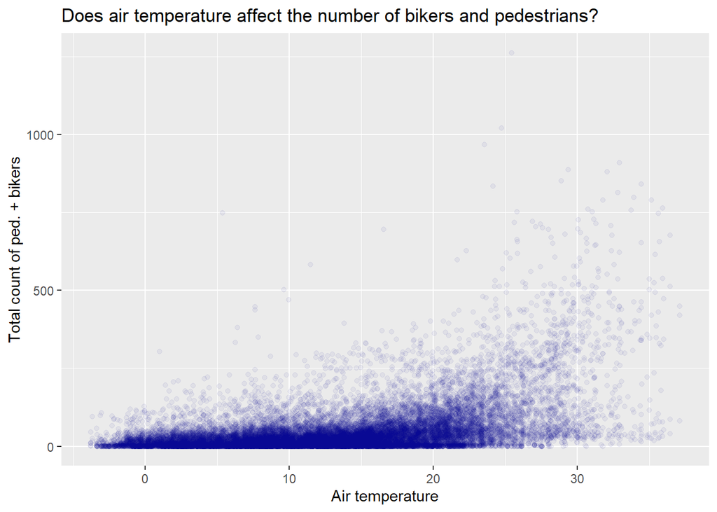

```r
#air temperature
ggplot(join_zaehlung_wetter, aes(air_temperature, UNIDIR)) + geom_point(alpha = 0.05, color="darkblue") + ggtitle("Does air temperature affect the number of bikers and pedestrians?") + xlab("Air temperature") + ylab("Total count of ped. + bikers")
```

```r
     # pch = 8,
     # col = "darkblue",
     # cex = 0.5,
     # main = ,
     # ylab =
     # xlab = ,
     # xlim = c(0,30)
#abline
#plot(aggregated_wetter_Wind_Temp_Prec_Hum$air_temperature, aggregated_wetter_Wind_Temp_Prec_Hum$UNIDIR, main = "...")
```

However, these hints need to be considered with attention. So it is that one has not taken into account yet at this point that the air temperature does not occur uniformely distributed.

As the extreme outliers distort the above illustration considerably, we take a closer look at how the points are distributed with an upper margin of 250 pedestrians and bikers per hour:

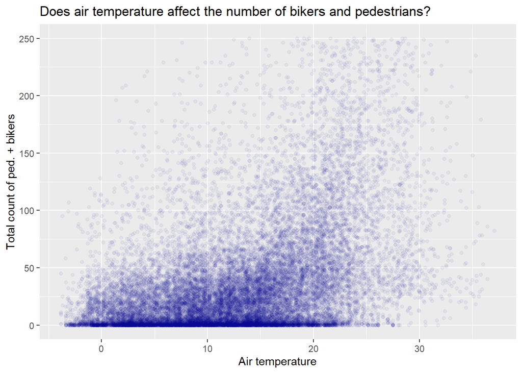

```r
ggplot(join_zaehlung_wetter, aes(air_temperature, UNIDIR)) + geom_point(alpha = 0.05, color="darkblue") + ggtitle("Does air temperature affect the number of bikers and pedestrians?") + xlab("Air temperature") + ylab("Total count of ped. + bikers") + ylim(c(0,250))
```

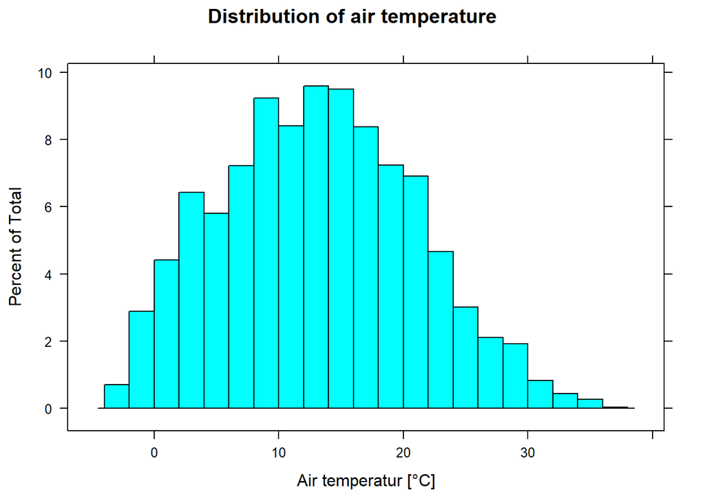

```r
histogram(~ air_temperature, data=join_zaehlung_wetter, xlab = "Air temperatur [°C]", main="Distribution of air temperature", breaks = 20)
```

As mentioned above, air temperature does not occur uniformely distributed. This illustration shows that the air temperature follow approximately a normal distribution instead.

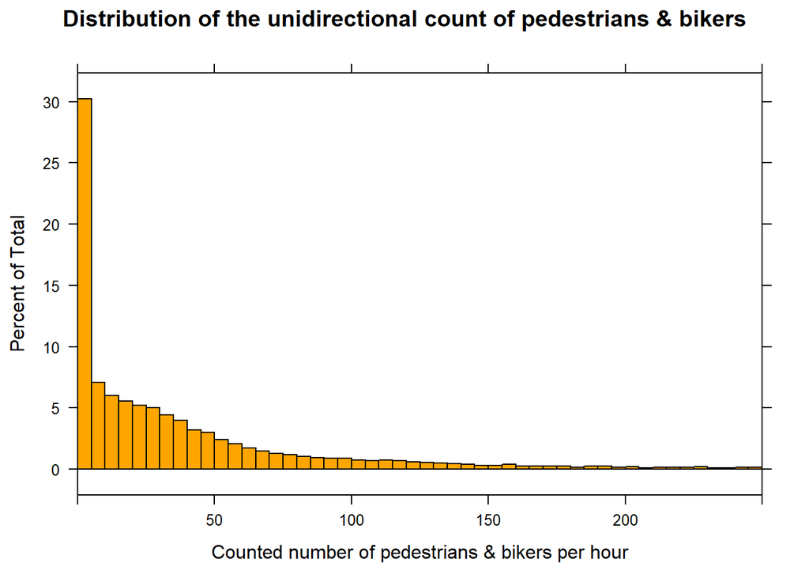

```r
histogram(~ join_zaehlung_wetter$UNIDIR, xlim = c(0,250), breaks = 250, xlab = "Counted number of pedestrians & bikers per hour", labels = TRUE, main="Distribution of the unidirectional count of pedestrians & bikers", col="orange")
```

The above illustration indicates that the data follows approximately an 1/x function. To normalize the data distribution for the unidirectional count of pedestrians & bikers, we logarithmize it to get appropr. normally distributed data.

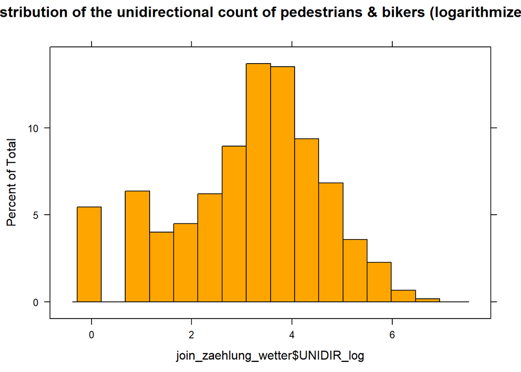

```r
join_zaehlung_wetter$UNIDIR_log <- log(join_zaehlung_wetter$UNIDIR)
histogram(~ join_zaehlung_wetter$UNIDIR_log, main = "Distribution of the unidirectional count of pedestrians & bikers (logarithmized)", col="orange")
```

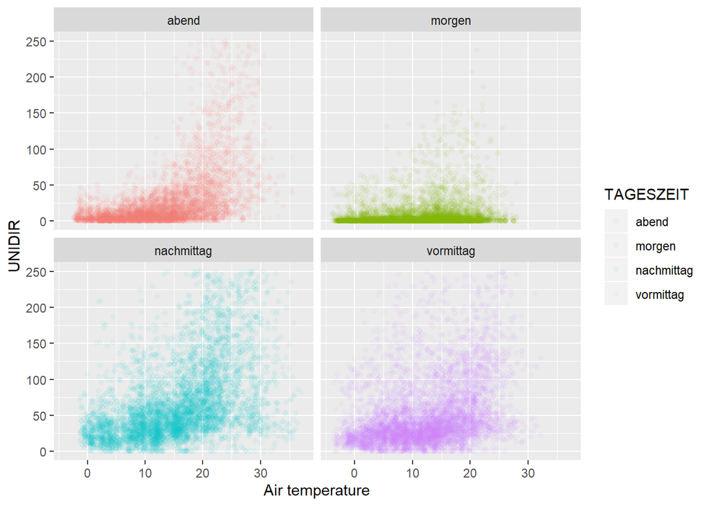

```r
## {ggplot2} ##
par(mfrow = c(2, 2))
qplot(y = UNIDIR, x = air_temperature, xlab = "Air temperature", data = join_zaehlung_wetter, facets = ~ TAGESZEIT, col = TAGESZEIT, ylim = c(0,250),alpha=I(0.05))
```

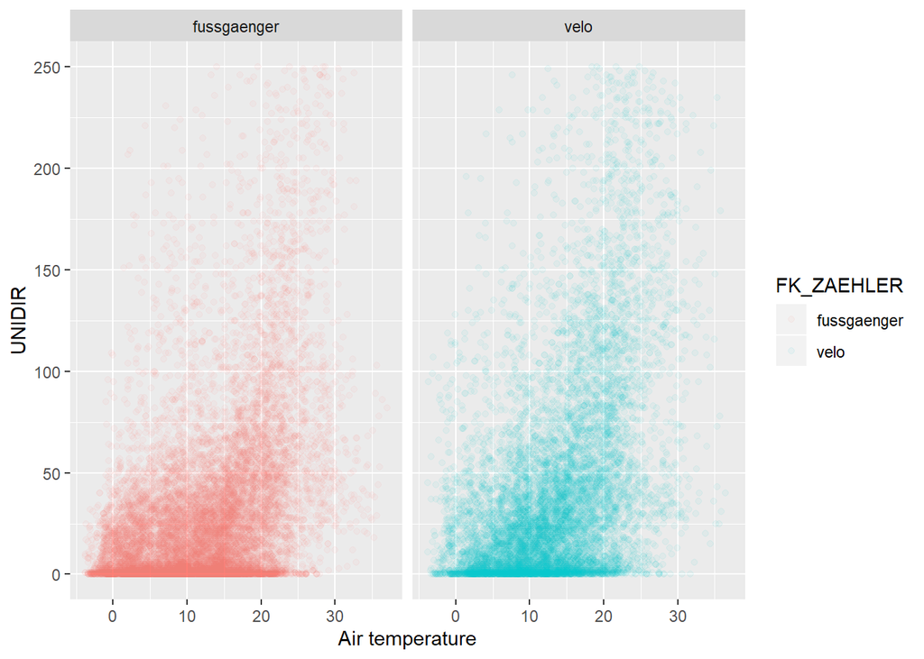

```r
qplot(y = UNIDIR, x = air_temperature, xlab = "Air temperature", data = join_zaehlung_wetter, facets = ~ FK_ZAEHLER, col = FK_ZAEHLER, ylim = c(0,250), alpha=I(0.05))
```

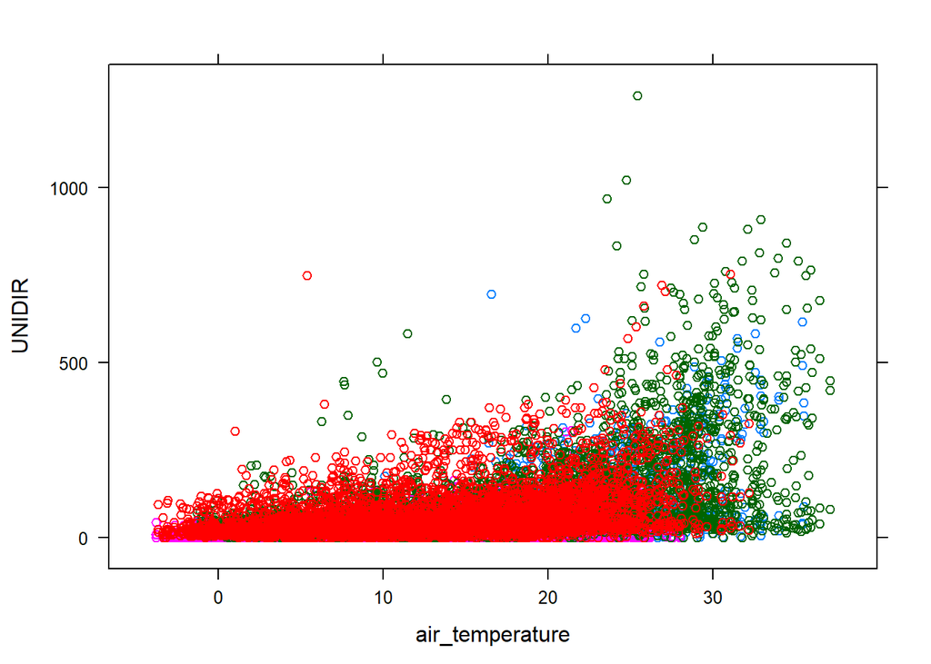

```r
xyplot(UNIDIR ~ air_temperature, groups = TAGESZEIT, data = join_zaehlung_wetter)
```

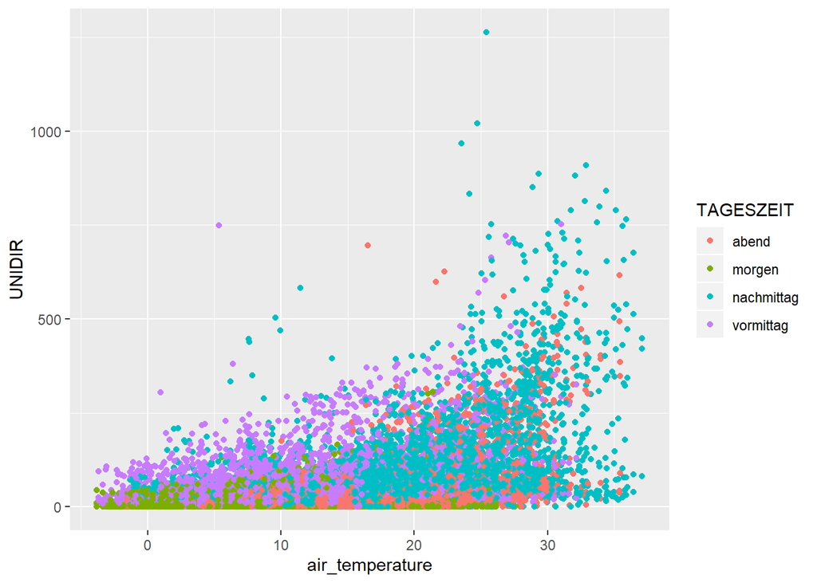

```r
ggplot(data = join_zaehlung_wetter,
       mapping = aes(y = UNIDIR,   #aes us easthetics
                     x = air_temperature,
                     colour = TAGESZEIT)) +
  geom_point()
```

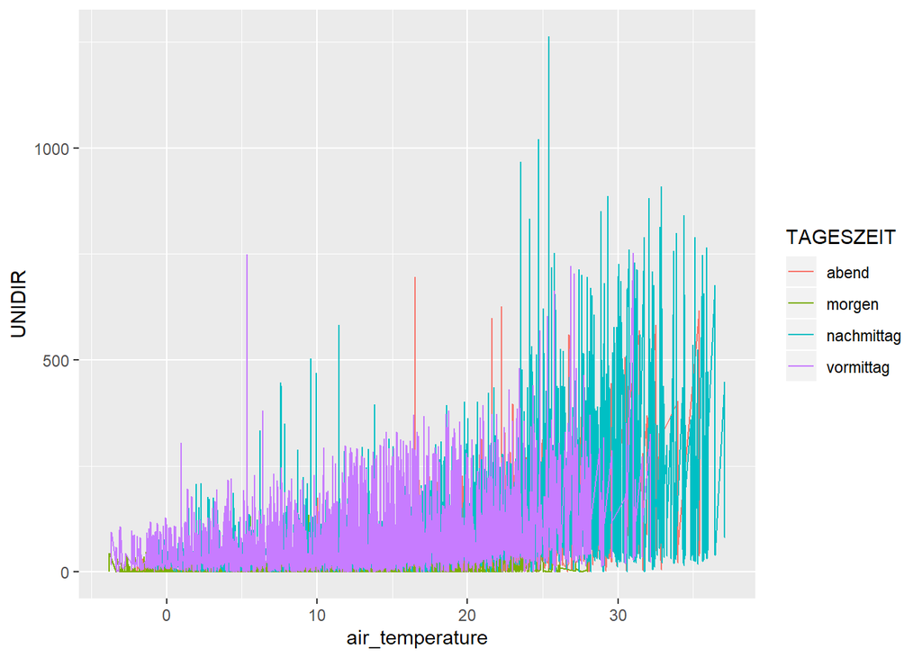

```r
ggplot(data = join_zaehlung_wetter,
       mapping = aes(y = UNIDIR,   #aes us easthetics
                     x = air_temperature,
                     colour = TAGESZEIT)) +
  geom_line()
```

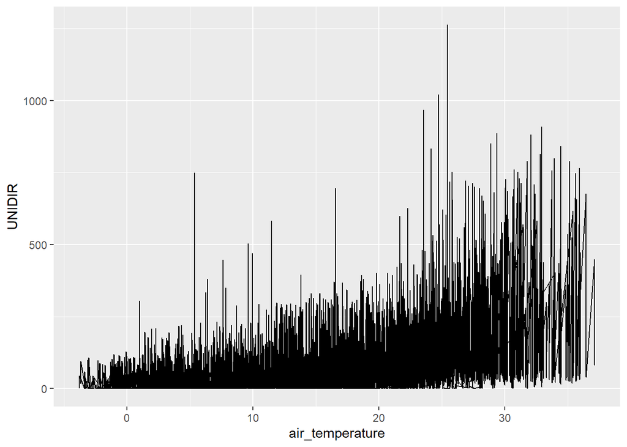

```r
ggplot(data = join_zaehlung_wetter,
       mapping = aes(y = UNIDIR,   #aes us easthetics
                     x = air_temperature,
                     group = TAGESZEIT)) +
  geom_line()
```

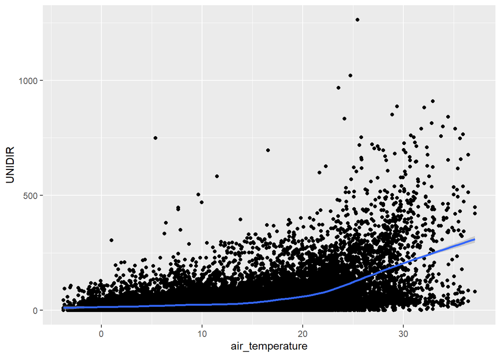

```r
ggplot(data = join_zaehlung_wetter,
       mapping = aes(y = UNIDIR,   #aes us easthetics
                     x = air_temperature)) +

  geom_point() +
  geom_smooth()
```

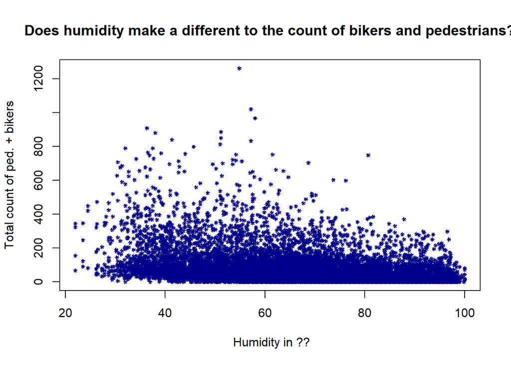

```r
#humidity
plot(UNIDIR ~ humidity, data = join_zaehlung_wetter,
     pch = 8,
     col = "darkblue",
     cex = 0.5,
     main = "Does humidity make a different to the count of bikers and pedestrians?",
     ylab = "Total count of ped. + bikers",
     xlab = " Humidity in ??")
```

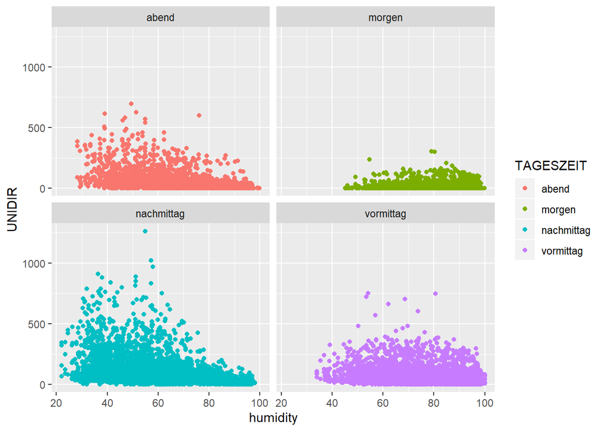

```r
par(mfrow = c(2, 2))
qplot(y = UNIDIR, x = humidity, data = join_zaehlung_wetter, facets = ~ TAGESZEIT, col = TAGESZEIT)
```

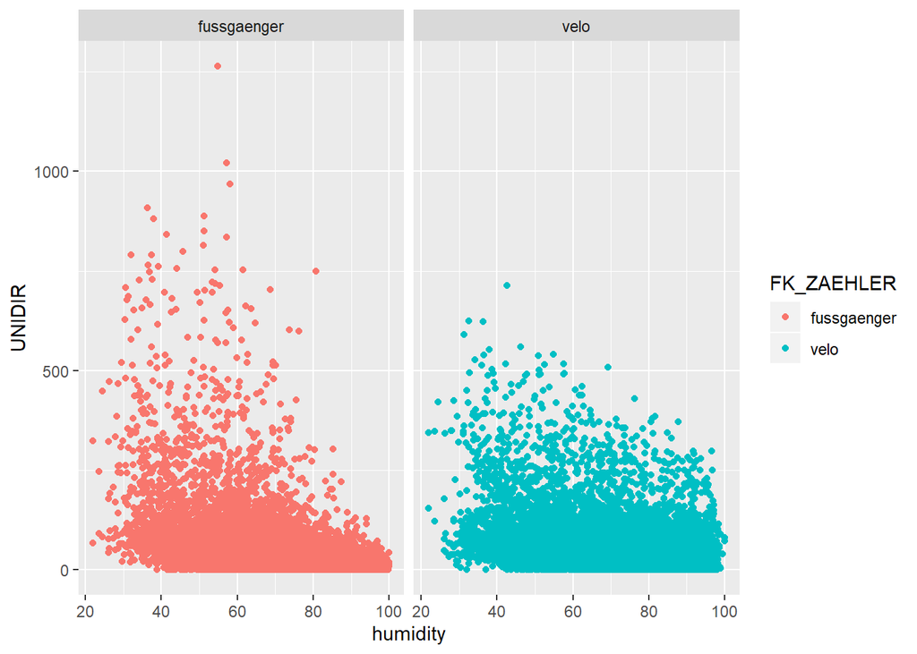

```r
qplot(y = UNIDIR, x = humidity, data = join_zaehlung_wetter, facets = ~ FK_ZAEHLER, col = FK_ZAEHLER)
```

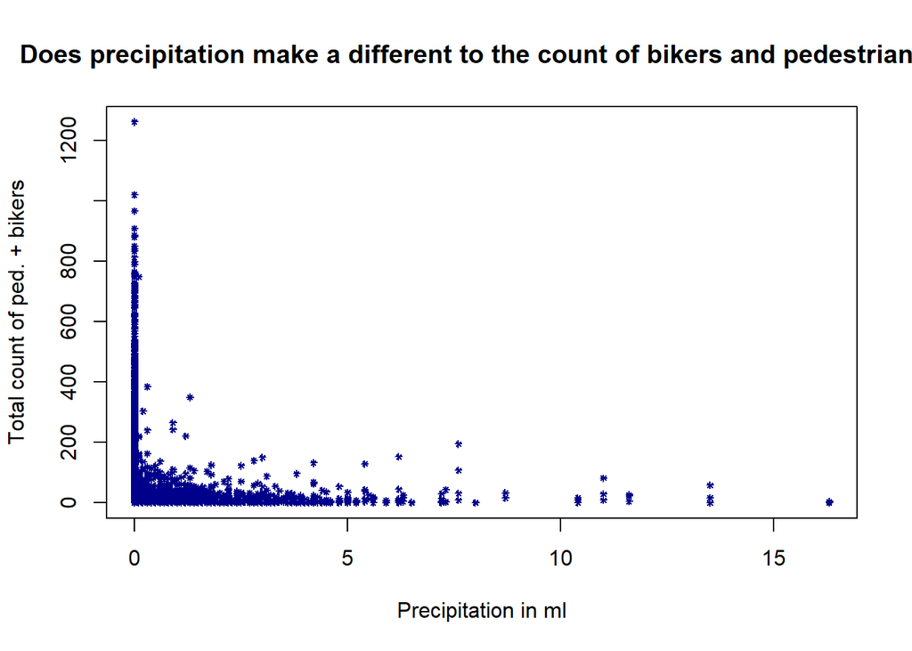

```r
#precipitation
plot(UNIDIR ~ precipitation, data = join_zaehlung_wetter,
     pch = 8,
     col = "darkblue",
     cex = 0.5,
     main = "Does precipitation make a different to the count of bikers and pedestrians?",
     ylab = "Total count of ped. + bikers",
     xlab = "Precipitation in ml")
```

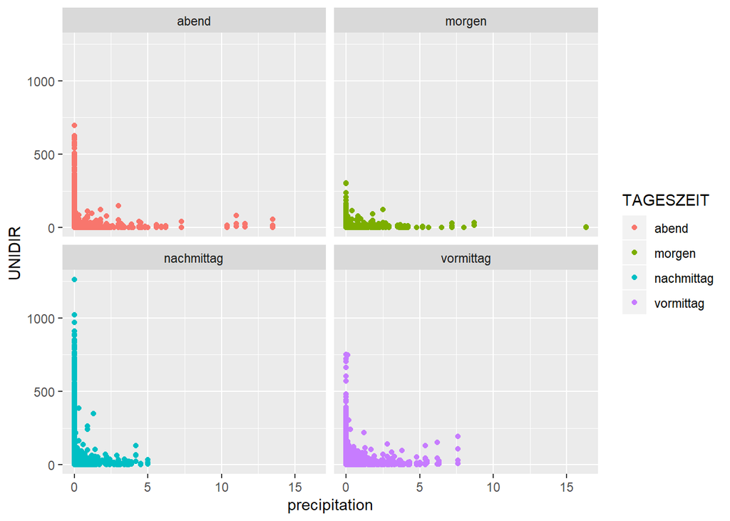

```r
qplot(y = UNIDIR, x = precipitation, data = join_zaehlung_wetter, facets = ~ TAGESZEIT, col = TAGESZEIT)
```

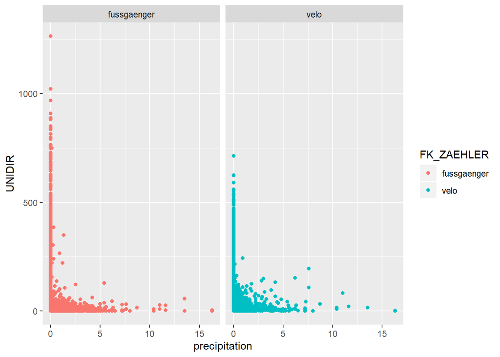

```r
qplot(y = UNIDIR, x = precipitation, data = join_zaehlung_wetter, facets = ~ FK_ZAEHLER, col = FK_ZAEHLER)
```

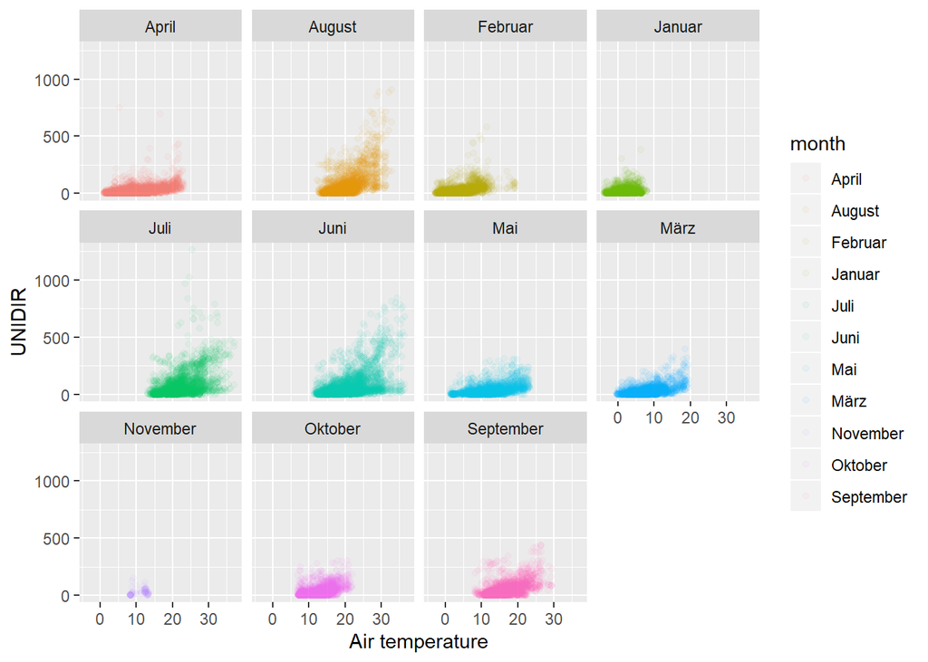

```r
qplot(y = UNIDIR, x = air_temperature, xlab = "Air temperature", data = join_zaehlung_wetter, facets = ~ month, col = month,alpha=I(0.05))
```

Discussion: very reliant on the quality of the data. (We do not know exactly how the counting stations worked)